# OncoImplexus Analysis Report: Sample

January 20, 2026

# Executive Summary

### Automated Findings Overview

No high-confidence catastrophic rearrangement events were detected in this sample. The genomic background is dominated by **NHEJ** repair signatures, with a median microhomology of 0 bp.

This report summarizes the complex chromosomal rearrangements detected in **H435**.

Summary of Detected Events

| Metric | Count | Status |
| --- | --- | --- |
| Chromothripsis (High Conf) | 0 | Not Detected |
| Chromothripsis (Low Conf) | 0 | Not Detected |
| Chromoplexy (Likely) | 0 | Not Detected |
| Chromoplexy (Possible) | 0 | Not Detected |
| Chromoanasynthesis (Likely) | 0 | Not Detected |
| Chromoanasynthesis (Possible) | 6 | Detected |

# Genomic Landscape Dashboard

This dashboard provides a multi-panel overview of structural variants, copy number profiles, and the distribution of detected chromoanagenesis events.

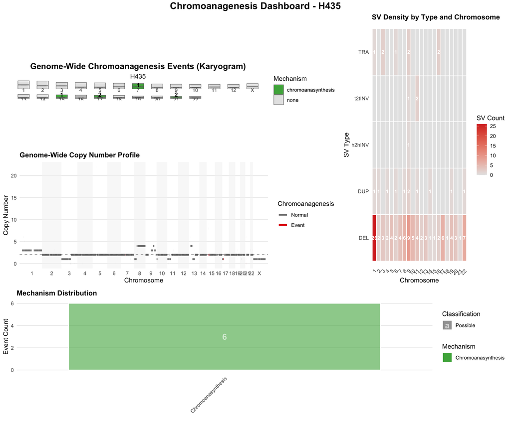

# Genome-Wide Visualization

This Circos plot integrates copy number variations (outer ring), detected chromoanagenesis regions (colored bands), and structural variant links.

[figure not shown]

# Functional Impact & Biological Insights

## 1. Driver Gene Impact

Analysis of cancer driver genes potentially impacted by the detected mechanisms.

```
## No high-confidence driver gene impacts were detected.
```

- **Consistent (TSG Loss)**: Tumor Suppressor Genes (TSGs) are disrupted or lost. This aligns with biological expectations as catastrophes typically lead to loss of gene function.
- **Consistent (Oncogene Amp)**: Oncogenes are amplified. This indicates that catastrophe events (e.g., Chromoanasynthesis) generated multiple copies, thereby activating the oncogene.
- **Potential Fusion/Disruption**: Potential gene fusion or structural disruption. For oncogenes, this may indicate the creation of a pathogenic fusion gene; for others, it represents a direct structural break.
- **Inconsistent (TSG Amp)**: Inconsistent status. A tumor suppressor gene is amplified, which is rare in tumor evolution and may not be the primary driver of this specific event.

## 2. Predicted Fusion Genes & Disruptions

Potential oncogenic fusion events or gene disruptions created by structural rearrangements.

|  | fusion_name | type | status | sv_type | orientation_compatible | sequence_preview |
| --- | --- | --- | --- | --- | --- | --- |
| 1 | CCDST::FLG | Fusion | Non-canonical (Intronic) | DEL | False | TCAGATCTTTCCTTG\|AGTCTTCTGAATGTC |
| 2 | SLC25A34::SLC25A34-AS1 | Fusion | Non-canonical (Intronic) | DEL | False | CCATAGGGGTCACTG\|CGCCGCACCGACCTT |
| 3 | NAV1::LOC124904483 | Fusion | Non-canonical (Intronic) | DEL | False | GAGGTCAGGAGTTCA\|AGACCAGCCTGGCCA |
| 4 | NAV1::IPO9-AS1 | Fusion | Non-canonical (Intronic) | DEL | False | GAGGTCAGGAGTTCA\|AGACCAGCCTGGCCA |
| 5 | LOC102724861::LINC00607 | Fusion | Non-canonical (Intronic) | DEL | False | GGGGAATGGCAGGAAA\|GACACACACAGAGCA |
| 6 | PTCH1::RALGPS1 | Fusion | Non-canonical (Intronic) | DUP | False | TGTCCTGGTGGTTGT\|CCCAGTGTTTGAGGA |
| 7 | LINC00899::TTC38 | Fusion | Non-canonical (Intronic) | DUP | False | GGAGGCAGCAGGGTCCC\|TCTCTCGGCAGGCAT |
| 8 | KIF1B::(intergenic) | Disruption | Intron disruption | DEL |  | CTTCTGATCCGCCTG\|CCTTGGCCTCCCAAA |
| 9 | DDHD2::(intergenic) | Disruption | Intron disruption | DEL |  | TGATCCGCCCACCTC\|GGCCTCCCAAAGTGC |
| 10 | PKN3::(intergenic) | Disruption | Intron disruption | DEL |  | CTCTACTACAAATACAAA\|AAAAATTAGCCGGGC |

[output cut: 77 more lines]

- **Canonical (Potential 5’->3’ fusion)**: The SV breakpoints join the 5’ part of one gene to the 3’ part of another in a way that allows for a continuous, functional fusion transcript. This status indicates high oncogenic potential.
- **Non-canonical (Orientation mismatch)**: Breakpoint orientations are incompatible for a standard 5’->3’ fusion (e.g., Head-to-Head or Tail-to-Tail joins). While they unlikely produce a functional fusion protein, they can still lead to gene truncation, loss of function, or enhancer hijacking.
- **Indeterminate**: The fusion potential cannot be accurately determined due to incomplete strand information or complex local rearrangements.

## 3. DNA Repair Mechanisms

Inferred DNA repair pathways (NHEJ, MMEJ, SSA, MMBIR) based on microhomology and insertion signatures at breakpoint junctions.

**[Click to Expand] View DNA Repair & Microhomology Details**

**Dominant Mechanism:** NHEJ  
**Median Microhomology:** 0 bp

#### Repair by SV Type

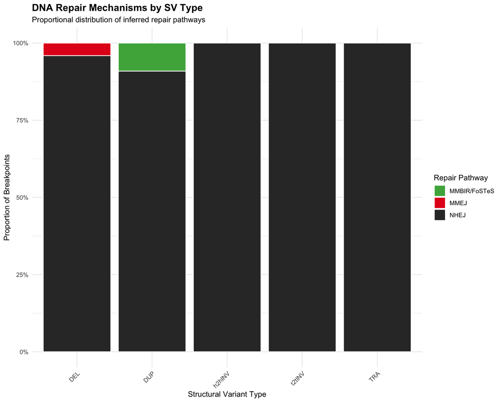

#### Microhomology Distribution

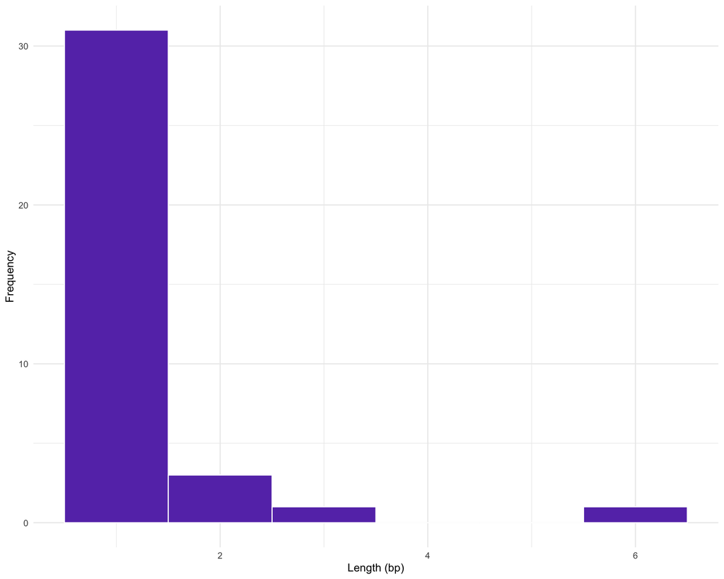

# Detailed Mechanism Findings

## 1. Chromothripsis

Characterized by localized shattering and random joining of DNA fragments.

```
## No significant chromothripsis events detected.
```

## 2. Chromoplexy

Characterized by chained translocations across multiple chromosomes.

```
## No chromoplexy chains detected.
```

## 3. Chromoanasynthesis

Characterized by replication-based mechanisms (FoSTeS) with copy number gradients.

|  | region_id | chrom | start | end | classification | max_chain_length | repair_signature |
| --- | --- | --- | --- | --- | --- | --- | --- |
| rho | 1 | 15 | 22648949 | 32225933 | Possible chromoanasynthesis | 0 | NHEJ (100%) |
| rho1 | 2 | 17 | 15140692 | 22745170 | Possible chromoanasynthesis | 0 | Unknown |
| rho2 | 3 | 17 | 19237312 | 26879829 | Possible chromoanasynthesis | 0 | Unknown |
| rho3 | 4 | 21 | 5218568 | 10467307 | Possible chromoanasynthesis | 0 | Unknown |
| rho4 | 5 | 21 | 7915997 | 10706511 | Possible chromoanasynthesis | 0 | Unknown |
| rho5 | 6 | 7 | 57126915 | 61962921 | Possible chromoanasynthesis | 0 | Unknown |

# Data Diagnostics

**OncoImplexus** Analysis | Generated on 2026-01-20 23:32:52.62471